# Unsupervised clustering

# Library

```r
library(ade4)
library(vegan)
library(gclus)
library(cluster)
library(rgl)
```

```r
library(scatterplot3d)
library(e1071)
library(multcompView)
library(labdsv)
library(kohonen)
library(MASS)
```

# Functions

## Rand index (Hubert and Arabie)

```r
#Plus ou moins un test du Chi-deux

AdjRkl <- function(part1, part2)
{
  confusion <- table(part1, part2)

  n <- sum(confusion)
  a <- sum(choose(confusion[confusion>1], 2))
  b <- apply(confusion, 1, sum)
  b <- sum(choose(b[b>1], 2))
  c <- apply(confusion, 2, sum)
  c <- sum(choose(c[c>1], 2))

  Rexp <- b*c/choose(n,2)
  (a - Rexp) / (.5*(b+c) - Rexp )
}
```

## Choose number of clusters

```r
Rousseuw <- function(x, dist, dendro = NULL, k)
{
  asw <- numeric(nrow(x))
  for (k in 2:(nrow(x)-1))
    {
      sil <- silhouette(cutree(dendro, k=k), dist)
      asw[k] <- summary(sil)$avg.width
    }
  k.best <- which.max(asw)

  # The plot is produced by function plot.silhouette {cluster}
  plot(1:nrow(x), asw, type="h",
       main="Silhouette-optimal number of clusters",
       xlab="k (number of groups)", ylab="Average silhouette width")
  axis(1, k.best, paste("optimum",k.best,sep="\n"), col="red", font=2,
       col.axis="red")
  points(k.best, max(asw), pch=16, col="red", cex=1.5)
  cat("", "Silhouette-optimal number of clusters k =", k.best, "\n",
      "with an average silhouette width of", max(asw), "\n")
}
```

## Choose number of clusters for PAM

```r
Rousseuw_PAM <- function (x, dist, k)
{
  asw <- numeric(nrow(spe))

  for (k in 2:(nrow(spe)-1))
    asw[k] <- pam(spe.ch, k, diss=TRUE)$silinfo$avg.width
  k.best <- which.max(asw)
  cat("", "Silhouette-optimal number of clusters k =", k.best, "\n",
      "with an average silhouette width of", max(asw), "\n")
  plot(1:nrow(spe), asw, type="h", main="Choice of the number of clusters",
       xlab="k (number of groups)", ylab="Average silhouette width")
  axis(1, k.best, paste("optimum",k.best,sep="\n"), col="red", font=2,
       col.axis="red")
  points(k.best, max(asw), pch=16, col="red", cex=1.5)
}
```

## plot cluster with colors on dendrogram

```r
hcoplot <- function(tree, diss, k, title=paste("Reordered dendrogram from",deparse(tree$call),sep="\n"))
{
  require(gclus)
  gr <- cutree(tree, k=k)
  tor <- reorder.hclust(tree, diss)
  plot(tor, hang=-1, xlab=paste(length(gr),"sites"), sub=paste(k,"groups"), main=title)
  so <- gr[tor$order]
  gro <- numeric(k)
  for (i in 1:k) {
    gro[i] <- so[1]
    if (i<k) so = so[so!=gro[i]]
  }
  rect.hclust(tor, k=k, border=gro+1, cluster=gr)
  legend("topright", paste("Group",1:k), pch=22, col=2:(k+1), bty="n")
}
```

## Silouhette plot

```r
silouhette_plot <- function(x, dist, dendro, k)
{
  cutg <- cutree(dendro, k=k)
  sil <- silhouette(cutg, dist)
  silo <- sortSilhouette(sil)
  rownames(silo) <- row.names(x)[attr(silo,"iOrd")]
  plot(silo, main="Silhouette plot - Chord",
       cex.names=0.8, col=cutg+1, nmax.lab=100)
}
```

Ce que le graphe nous montre :

- Couleurs : répartition des individus dans un groupe –> 1 couleur = 1 groupe
- Axe Silhouette width : mesure de similarité de l’individu avec son propre cluster –> Barre colorée grande (proche de 1) = individu en harmonie avec son cluster
- Nombres à coté des barres colorées : numéro du cluster, nombre d’individus dans le cluster, moyenne des mesures de similarité des individus composant le cluster –> valeur proche de 1 = cluster homogène
- Average silhouette width : homogénéité moyenne –> valeur proche de 1 = clustering homogène possible

## Plot cluster on a map if coordinates are available

```r
cluster_map <- function(coor, cutree)
{
  plot(coor, asp=1, type="n", main="Four Ward groups",
       xlab="x coordinate (km)", ylab="y coordinate (km)")
  lines(coor, col="light blue")
  text(50, 10, "Upstream", cex=1.2, col="red")
  text(25, 115, "Downstream", cex=1.2, col="red")

  # Add the four groups
  grw <- cutree
  k <- length(levels(factor(grw)))
  for (i in 1:k) {
    points(coor[grw==i,1], coor[grw==i,2], pch=i+20, cex=3, col=i+1, bg=i+1)
  }
  text(coor, row.names(coor), cex=0.8, col="white", font=2)
  legend("bottomright", paste("Group",1:k), pch=(1:k)+20, col=2:(k+1),
         pt.bg=2:(k+1), pt.cex=2, bty="n")
}
```

## Abundant species in clusters

```r
abundant_groups <- function (x, cluster)
{
  groups <- as.factor(spe.kmeans$cluster)
  spe.means <- matrix(0, ncol(spe), length(levels(groups)))
  row.names(spe.means) <- colnames(spe)
  for(i in 1:ncol(spe))
  {
    spe.means[i,] <- tapply(spe[,i], spe.kmeans$cluster, mean)
  }
  return(spe.means)
}
```

## Indicator species in clusters (Dufrene and Legendre)

```r
indicator <- function(x, y, k)
{
  das.D1 <- dist(data.frame(das=y[,1], row.names=rownames(y)))
  dasD1.kmeans <- kmeans(das.D1, centers=k, nstart=100)
  dasD1.kmeans$cluster

  #Indicator species for this typology of the sites
  iva <- indval(x, dasD1.kmeans$cluster)
  iva

  #Table of the significant indicator species
  gr <- iva$maxcls[iva$pval<=0.05]
  iv <- iva$indcls[iva$pval<=0.05]
  pv <- iva$pval[iva$pval<=0.05]
  fr <- apply(x>0, 2, sum)[iva$pval<=0.05]
  fidg <- data.frame(group=gr, indval=iv, pvalue=pv, freq=fr)
  fidg <- fidg[order(fidg$group, -fidg$indval),]
  return(fidg)
}
```

# Data

## Read

```r
data(doubs)
data(iris)
data(lascaux)
```

## Rename

```r
#Doubs
spe <- doubs$fish
env <- doubs$env
spa <- doubs$xy
```

```r
#Iris
iris.var <- iris[,c(1:4)]
```

# Matrices de distances

```r
# Verify if empty sites exist
apply(spe, 1, max)
```

```
##  1  2  3  4  5  6  7  8  9 10 11 12 13 14 15 16 17 18 19 20 21 22 23 24 25
##  3  5  5  5  5  5  5  0  5  4  4  5  5  5  5  5  4  3  5  5  5  5  2  5  3
## 26 27 28 29 30
##  5  5  5  5  5
```

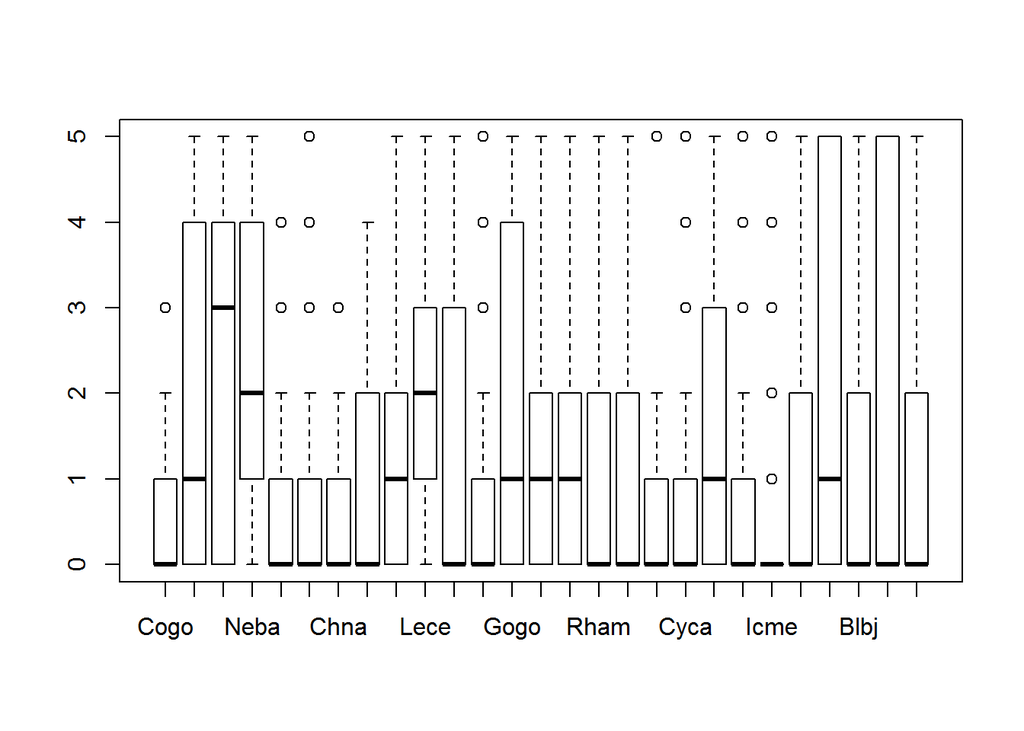

```r
# Remove the site where there is no fish
spe = spe[-8,]
env = env[-8,]
spa = spa[-8,]

# Check heterogeneity
boxplot(spe)
```

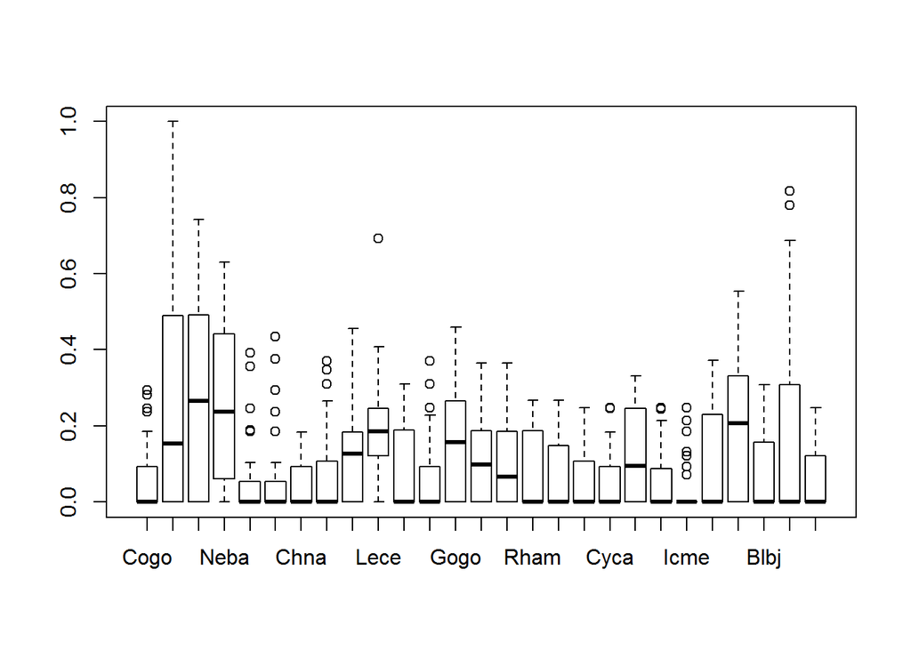

```r
# Normalize (scale between 0 and 1)
# Standardize (scale between -3 and 3)
spe.norm <- decostand (spe, "normalize")
boxplot(spe.norm)
```

```r
# Matrix distance
spe.ch <- dist(spe.norm)
```

# Dendrograms

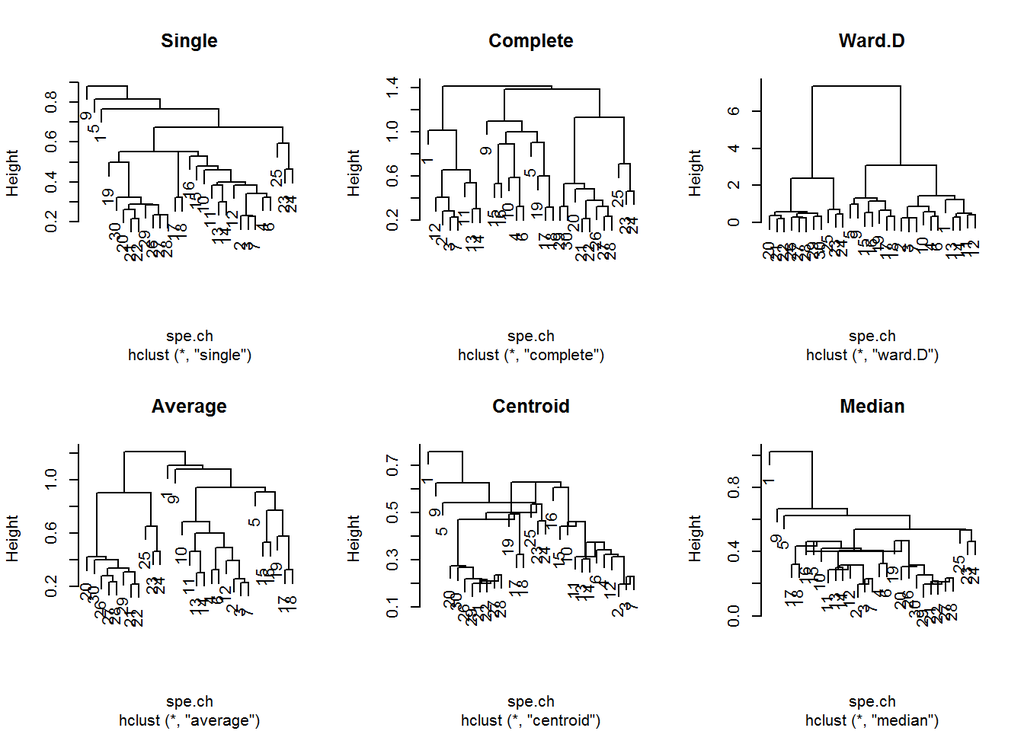

```r
par(mfrow = c(2,3))

spe.ch.single <- hclust(spe.ch, method = "single")
plot(spe.ch.single, main = "Single")

spe.ch.complete <- hclust(spe.ch, method = "complete")
plot(spe.ch.complete, main = "Complete")

spe.ch.ward <- hclust(spe.ch, method = "ward.D")
plot(spe.ch.ward, main = "Ward.D")

spe.ch.average <- hclust(spe.ch, method = "average")
plot(spe.ch.average, main = "Average")

spe.ch.centroid <- hclust(spe.ch, method = "centroid")
plot(spe.ch.centroid, main = "Centroid")

spe.ch.median <- hclust(spe.ch, method = "median")
plot(spe.ch.median, main = "Median")
```

## Which method is better ?

### Cophenetic correlation

```r
spe.ch.ward.coph <- cophenetic(spe.ch.ward)
cor(spe.ch, spe.ch.ward.coph)
```

```
## [1] 0.7593934
```

```r
spe.ch.single.coph <- cophenetic(spe.ch.single)
cor(spe.ch, spe.ch.single.coph)
```

```
## [1] 0.599193
```

```r
spe.ch.complete.coph <- cophenetic(spe.ch.complete)
cor(spe.ch, spe.ch.complete.coph)
```

```
## [1] 0.7655628
```

```r
spe.ch.median.coph <- cophenetic(spe.ch.median)
cor(spe.ch, spe.ch.median.coph)
```

```
## [1] 0.3989109
```

```r
spe.ch.centroid.coph <- cophenetic(spe.ch.centroid)
cor(spe.ch, spe.ch.centroid.coph)
```

```
## [1] 0.8452856
```

```r
spe.ch.average.coph <- cophenetic(spe.ch.average)
cor(spe.ch, spe.ch.average.coph)
```

```
## [1] 0.8608326
```

UPGMA seems to be the best method. But this method don’t always give the best result, the best solution

### Shepard-like diagrams

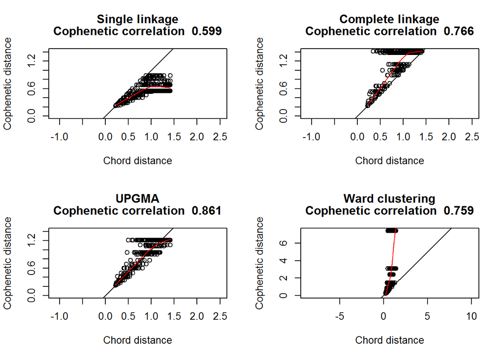

```r
par(mfrow=c(2,2))

plot(spe.ch, spe.ch.single.coph, xlab="Chord distance",
     ylab="Cophenetic distance", asp=1, xlim=c(0,sqrt(2)), ylim=c(0,sqrt(2)),
     main=c("Single linkage",paste("Cophenetic correlation ",
                                   round(cor(spe.ch, spe.ch.single.coph),3))))
abline(0,1)
lines(lowess(spe.ch, spe.ch.single.coph), col="red")

plot(spe.ch, spe.ch.complete.coph, xlab="Chord distance",
     ylab="Cophenetic distance", asp=1, xlim=c(0,sqrt(2)), ylim=c(0,sqrt(2)),
     main=c("Complete linkage", paste("Cophenetic correlation ",
                                      round(cor(spe.ch, spe.ch.complete.coph),3))))
abline(0,1)
lines(lowess(spe.ch, spe.ch.complete.coph), col="red")

plot(spe.ch, spe.ch.average.coph, xlab="Chord distance",
     ylab="Cophenetic distance", asp=1, xlim=c(0,sqrt(2)), ylim=c(0,sqrt(2)),
     main=c("UPGMA", paste("Cophenetic correlation ",
                           round(cor(spe.ch, spe.ch.average.coph),3))))
abline(0,1)
lines(lowess(spe.ch, spe.ch.average.coph), col="red")

plot(spe.ch, spe.ch.ward.coph, xlab="Chord distance",
     ylab="Cophenetic distance", asp=1, xlim=c(0,sqrt(2)), ylim=c(0,max(spe.ch.ward$height)),
     main=c("Ward clustering", paste("Cophenetic correlation ",
                                     round(cor(spe.ch, spe.ch.ward.coph),3))))
abline(0,1)
lines(lowess(spe.ch, spe.ch.ward.coph), col="red")
```

## How many groups?

### Fusion level values

```r
par(mfrow=c(2,2))
summary(spe.ch.single)  #List of available results
```

```
##             Length Class  Mode
## merge       56     -none- numeric
## height      28     -none- numeric
## order       29     -none- numeric
## labels      29     -none- character
## method       1     -none- character
## call         3     -none- call
## dist.method  1     -none- character
```

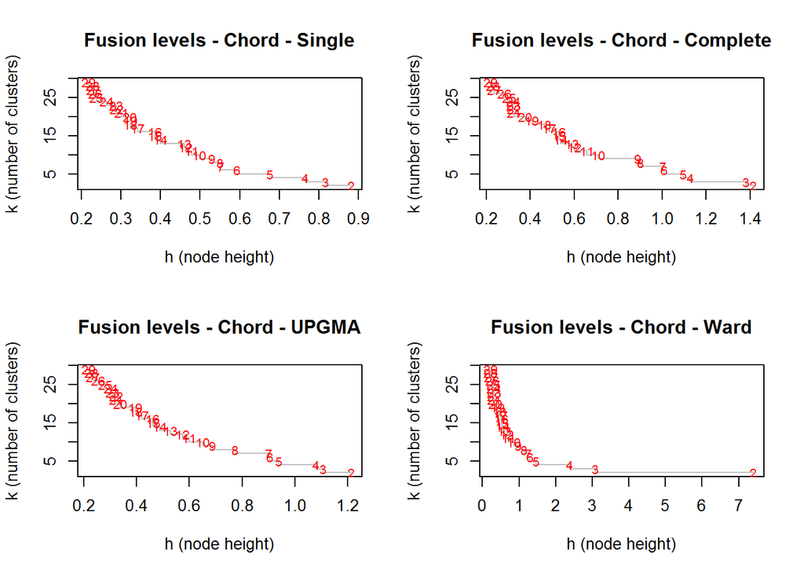

```r
plot(spe.ch.single$height, nrow(spe):2, type="S",
     main="Fusion levels - Chord - Single",
     ylab="k (number of clusters)", xlab="h (node height)", col="grey")
text(spe.ch.single$height, nrow(spe):2, nrow(spe):2, col="red", cex=0.8)

plot(spe.ch.complete$height, nrow(spe):2, type="S",
     main="Fusion levels - Chord - Complete",
     ylab="k (number of clusters)", xlab="h (node height)", col="grey")
text(spe.ch.complete$height, nrow(spe):2, nrow(spe):2, col="red", cex=0.8)

plot(spe.ch.average$height, nrow(spe):2, type="S",
     main="Fusion levels - Chord - UPGMA",
     ylab="k (number of clusters)", xlab="h (node height)", col="grey")
text(spe.ch.average$height, nrow(spe):2, nrow(spe):2, col="red", cex=0.8)

plot(spe.ch.ward$height, nrow(spe):2, type="S",
     main="Fusion levels - Chord - Ward",
     ylab="k (number of clusters)", xlab="h (node height)", col="grey")
text(spe.ch.ward$height, nrow(spe):2, nrow(spe):2, col="red", cex=0.8)
```

h (node heigth) –> distance between groups The distance must be high between groups to become the good method See all the check-methods to decide Goal : the more parcimonious groupment with homogeneous groups

### Rousseeuw quality index

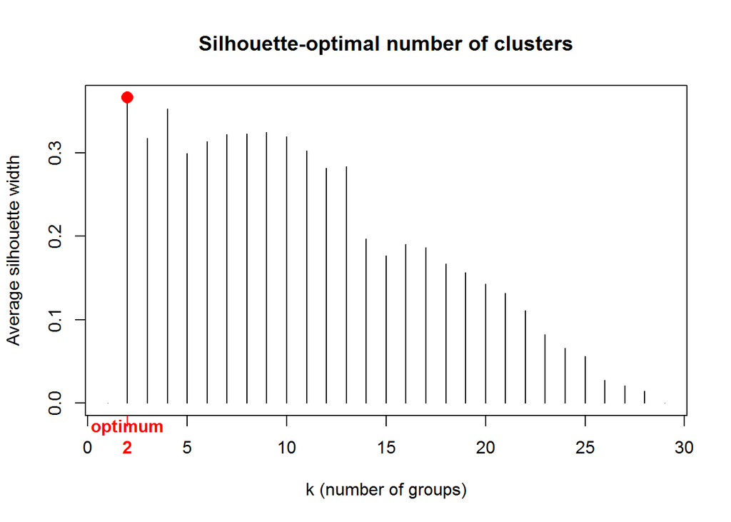

```
##  Silhouette-optimal number of clusters k = 2
##  with an average silhouette width of 0.3658319
```

```r
Rousseuw(x = spe, dist = spe.ch, dendro = spe.ch.ward, k = 4)
```

Plot average silhouette widths (using Ward clustering) for all partitions except for the trivial partition in a single group (k=1). First, create an empty vector in which the asw values will be written good cluster number = high silhouette value

Two clusters are the best choice but the second better choice is 4. It is the better choice in ecology

Choose 4 groups according to all methods

```r
k <- 4
```

```r
#Cut the tree
spebc.single.g <- cutree(spe.ch.single, k)
spebc.complete.g <- cutree(spe.ch.complete, k)
spebc.average.g <- cutree(spe.ch.average, k)
spebc.ward.g <- cutree(spe.ch.ward, k)

table(spebc.average.g, spebc.ward.g) #To see common groups in both methods
```

```
##                spebc.ward.g
## spebc.average.g  1  2  3  4
##               1  1  0  0  0
##               2 10  6  0  0
##               3  0  1  0  0
##               4  0  0  8  3
```

```r
table(spebc.average.g, spebc.single.g)
```

```
##                spebc.single.g
## spebc.average.g  1  2  3  4
##               1  1  0  0  0
##               2  0 15  1  0
##               3  0  0  0  1
##               4  0 11  0  0
```

```r
table(spebc.average.g, spebc.complete.g)
```

```
##                spebc.complete.g
## spebc.average.g 1 2 3 4
##               1 1 0 0 0
##               2 7 9 0 0
##               3 0 1 0 0
##               4 0 0 8 3
```

```r
table(spebc.single.g, spebc.complete.g)
```

```
##               spebc.complete.g
## spebc.single.g 1 2 3 4
##              1 1 0 0 0
##              2 7 8 8 3
##              3 0 1 0 0
##              4 0 1 0 0
```

```r
table(spebc.single.g, spebc.ward.g)
```

```
##               spebc.ward.g
## spebc.single.g  1  2  3  4
##              1  1  0  0  0
##              2 10  5  8  3
##              3  0  1  0  0
##              4  0  1  0  0
```

```r
table(spebc.ward.g, spebc.complete.g)
```

```
##             spebc.complete.g
## spebc.ward.g 1 2 3 4
##            1 8 3 0 0
##            2 0 7 0 0
##            3 0 0 8 0
##            4 0 0 0 3
```

Agree for the majority but differencies.

## How to quantify differencies?

```r
AdjRkl(spebc.single.g, spebc.complete.g)
```

```
## [1] -0.02477152
```

```r
AdjRkl(spebc.single.g, spebc.average.g)
```

```
## [1] 0.1811765
```

```r
AdjRkl(spebc.single.g, spebc.ward.g)
```

```
## [1] 0.002664349
```

```r
AdjRkl(spebc.ward.g, spebc.complete.g)
```

```
## [1] 0.7118751
```

```r
AdjRkl(spebc.ward.g, spebc.average.g)
```

```
## [1] 0.4730147
```

```r
AdjRkl(spebc.average.g, spebc.complete.g)
```

```
## [1] 0.4560189
```

The more is the index, the more the methods are confusive Ward and Complete give very similar results

## Final partition

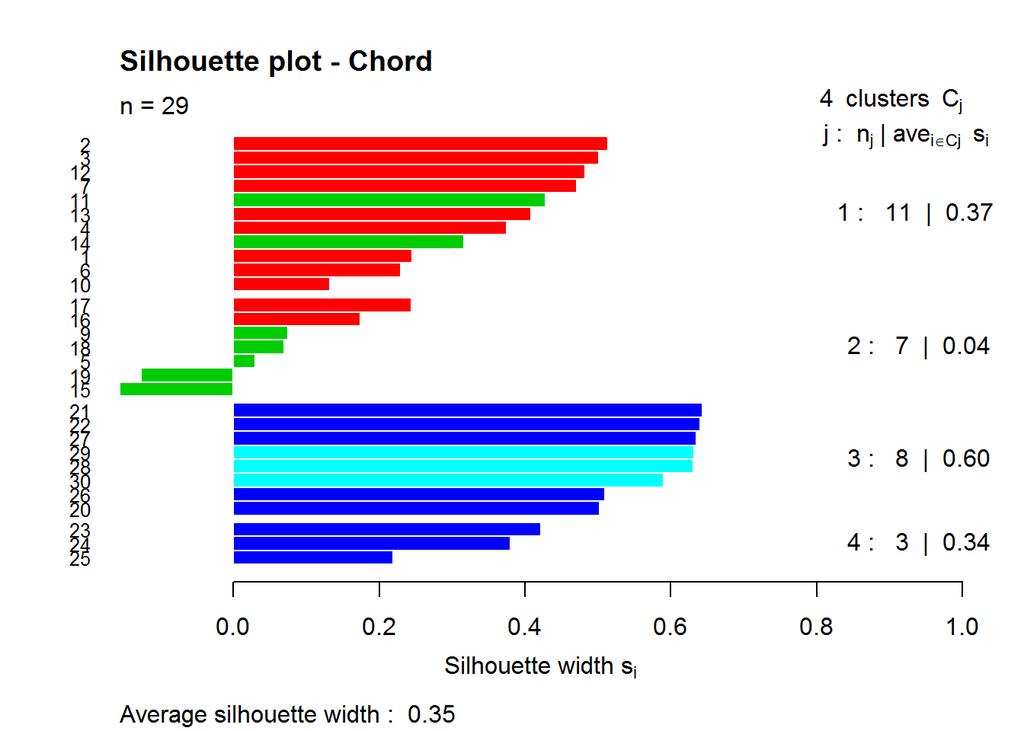

```r
silouhette_plot(spe, spe.ch, spe.ch.ward, 4)
```

Higher is the coefficient, better is High coefficient : homogeneous group Low coefficient : no homogeneous but they have to be placed somewhere

## Dendrogram with colors of groups

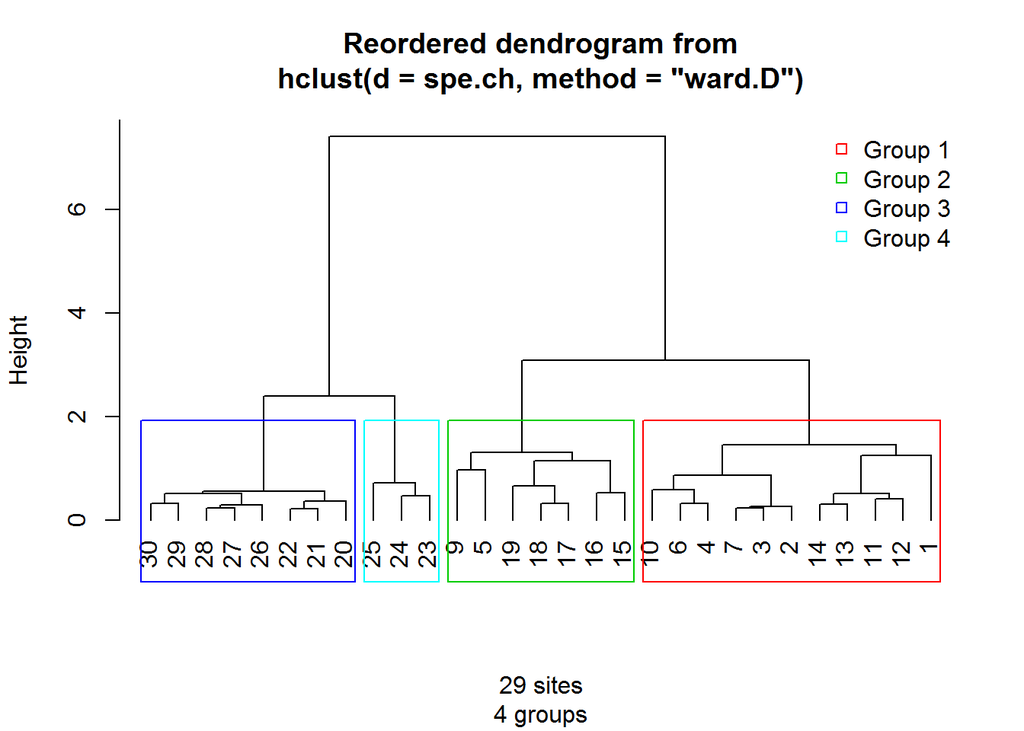

```r
hcoplot(spe.ch.ward, spe.ch, k)
```

## Plot of the 4 clusters on a map of the Doubs river

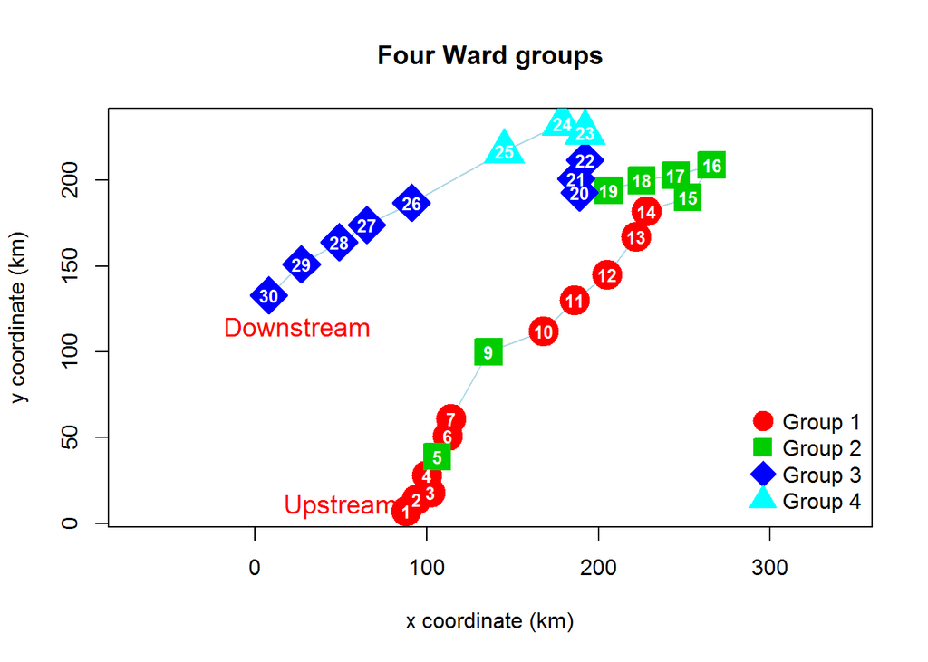

```r
cluster_map(spa, spebc.ward.g)
```

There is a continuity but with some problems Ecology can answer these problems : river cut off with a barrier, etc…

# AGNES

Agglomerative hierarchical clustering

```r
#Use Ward method according to check-methods above
agnes1 <- agnes(spe.norm, method = "ward")
par(mfrow = c(1,2))
agnes1
```

```
## Call:     agnes(x = spe.norm, method = "ward")
## Agglomerative coefficient:  0.8777742
## Order of objects:
##  [1] 1  2  3  7  4  6  10 11 12 13 14 5  9  15 16 17 18 19 20 21 22 26 27
## [24] 28 29 30 23 24 25
## Height (summary):
##    Min. 1st Qu.  Median    Mean 3rd Qu.    Max.
##  0.2183  0.3233  0.5087  0.7650  0.9880  3.5940
##
## Available components:
## [1] "order"     "height"    "ac"        "merge"     "diss"      "call"
## [7] "method"    "order.lab" "data"
```

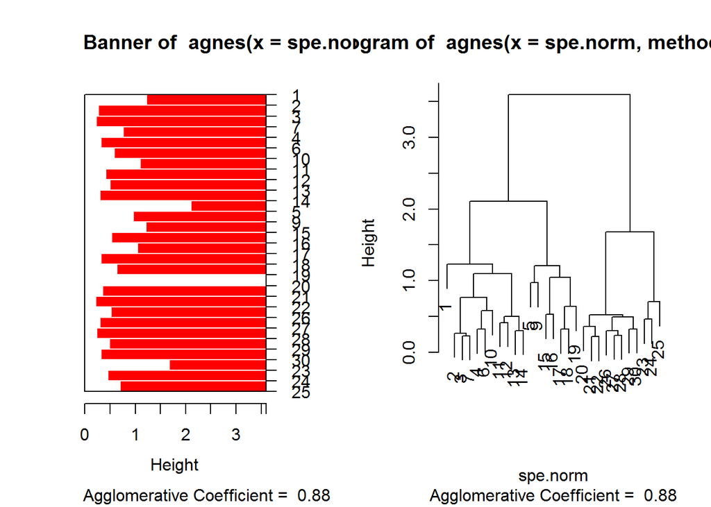

```r
plot(agnes1)
```

Very good agglomerative coefficient close to 1 2 well differenciated cluster (blank between) But we can differenciate other groups (littlest bar)

```r
#Use method UPGM average - The best according to cophenetic correlation #
agnes2 <- agnes(spe.norm, method = "average")
par(mfrow = c(1,2))
agnes2
```

```
## Call:     agnes(x = spe.norm, method = "average")
## Agglomerative coefficient:  0.6367702
## Order of objects:
##  [1] 1  2  3  7  12 4  6  11 13 14 10 5  15 16 17 18 19 9  20 21 22 29 26
## [24] 27 28 30 23 24 25
## Height (summary):
##    Min. 1st Qu.  Median    Mean 3rd Qu.    Max.
##  0.2183  0.3189  0.4624  0.5500  0.7080  1.2130
##
## Available components:
## [1] "order"     "height"    "ac"        "merge"     "diss"      "call"
## [7] "method"    "order.lab" "data"
```

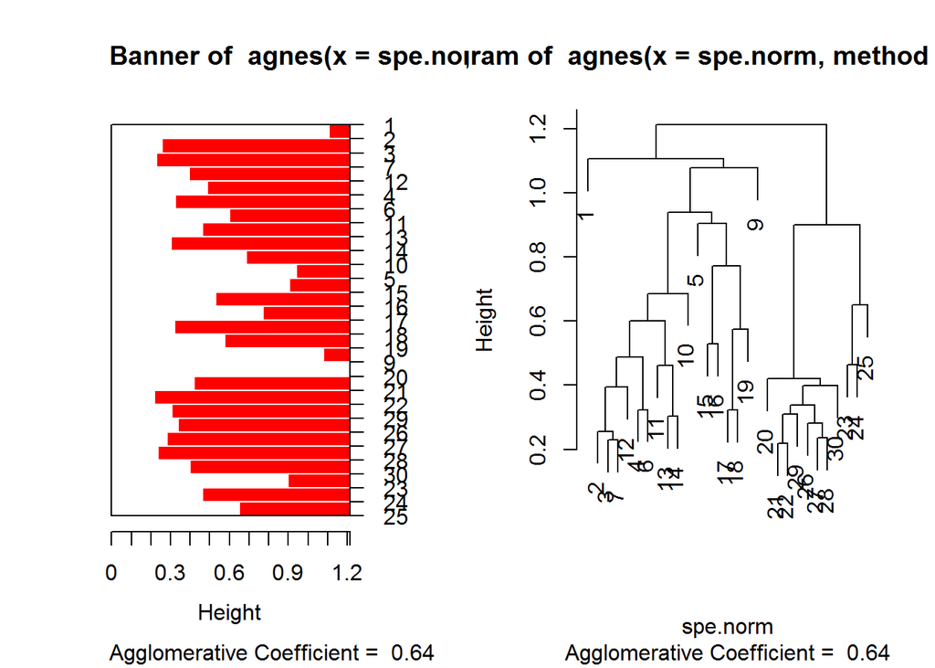

```r
plot(agnes2)
```

Lower agglomerative coefficient

## AGNES VS Ward Method

```r
#Choose the number of cluster
clas.agnes <- cutree(agnes1,k)
table(cutree(agnes1,k))
```

```
##
##  1  2  3  4
## 11  7  8  3
```

```r
table(cutree(agnes1,k), spebc.ward.g)
```

```
##    spebc.ward.g
##      1  2  3  4
##   1 11  0  0  0
##   2  0  7  0  0
##   3  0  0  8  0
##   4  0  0  0  3
```

```r
AdjRkl(cutree(agnes1,k), spebc.ward.g)
```

```
## [1] 1
```

Perfect confusive table - Coefficient = 1 - Same results

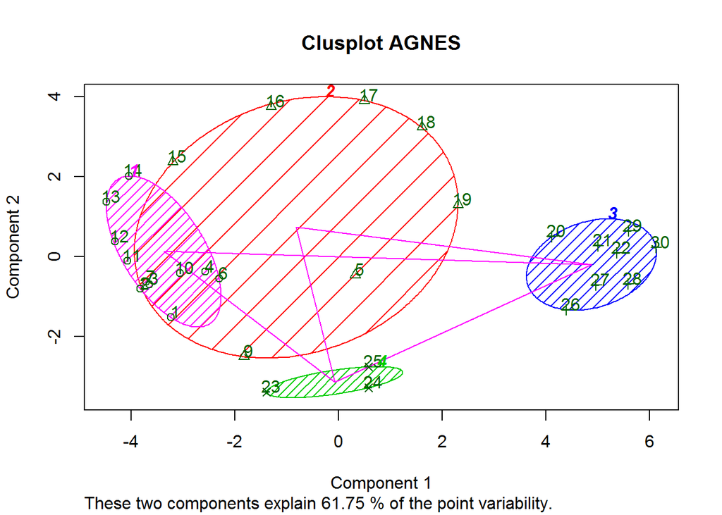

```r
clusplot(spe.norm, clas.agnes,
         color = T, shade = T, labels = 2, lines = 1,
         main = "Clusplot AGNES")
```

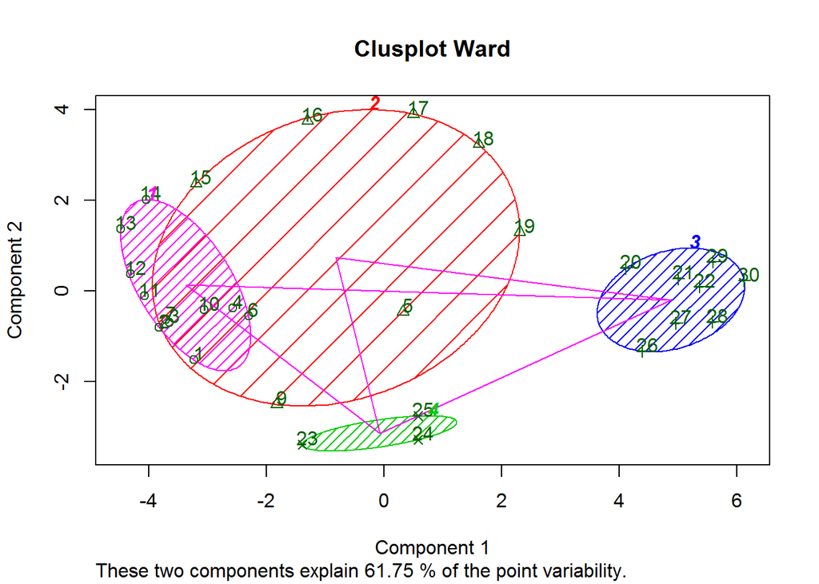

```r
clusplot(spe.norm, spebc.ward.g,
         color = T, shade = T, labels = 2, lines = 1,
         main = "Clusplot Ward")
```

If two groups are linked by a line, there are different If not, there are not different Groups with lower within ss are well differenciated on the graph

```r
table(spebc.ward.g, clas.agnes)
```

```
##             clas.agnes
## spebc.ward.g  1  2  3  4
##            1 11  0  0  0
##            2  0  7  0  0
##            3  0  0  8  0
##            4  0  0  0  3
```

Same graphics - Same results

# DIANA

Divisive hierarchical clustering

```r
diana1 <- diana(spe.norm, metric = "euclidian")
par(mfrow = c(1,2))
diana1
```

```
## Merge:
##       [,1] [,2]
##  [1,]  -20  -21
##  [2,]   -3   -7
##  [3,]  -26  -27
##  [4,]   -2    2
##  [5,]  -12  -13
##  [6,]   -4   -6
##  [7,]  -28  -29
##  [8,]  -25    3
##  [9,]  -19    1
## [10,]    4  -11
## [11,]  -22  -23
## [12,]    8    7
## [13,]  -14  -15
```

[output cut: 29 more lines]

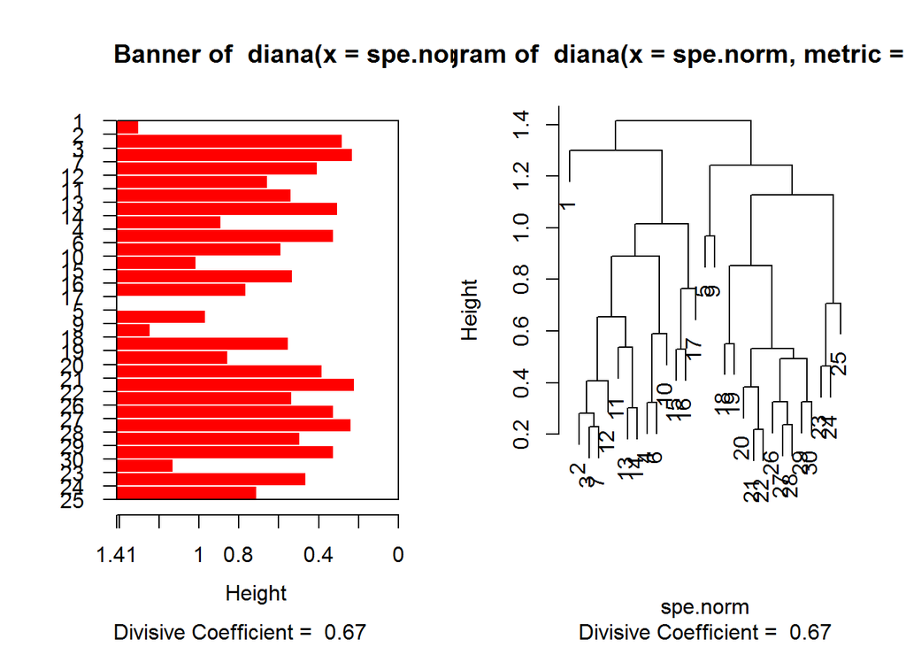

```r
plot(diana1)
```

Coefficient lower than agnes cause diana group down. It is easier to aggregate than divide

```r
diana1 <- diana(spe.norm, metric = "manhattan")
par(mfrow = c(1,2))
diana1
```

```
## Merge:
##       [,1] [,2]
##  [1,]   -2   -3
##  [2,]    1   -7
##  [3,]  -10  -11
##  [4,]  -25  -26
##  [5,]  -12  -13
##  [6,]  -20  -21
##  [7,]   -4   -6
##  [8,]  -27  -29
##  [9,]    2    3
## [10,]    8  -28
## [11,]  -19    6
## [12,]    7   -9
## [13,]    9    5
```

[output cut: 29 more lines]

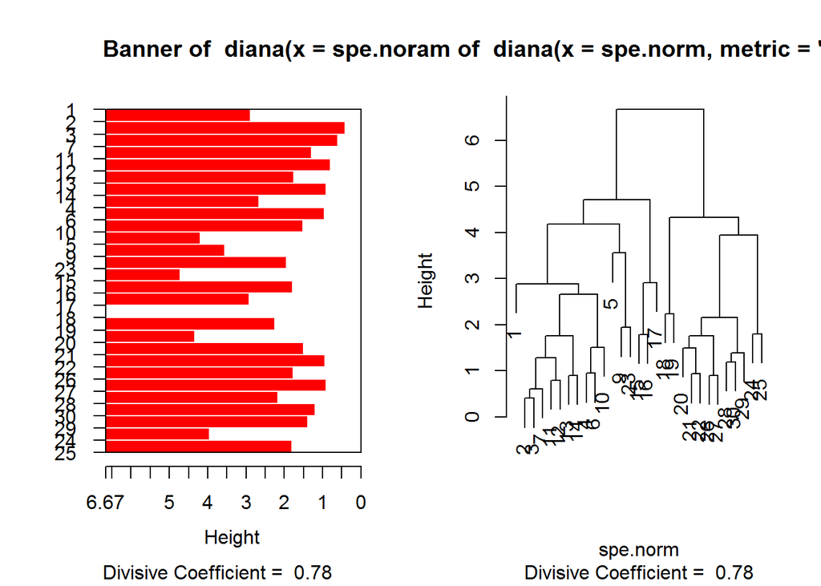

```r
plot(diana1)
```

## DIANA VS AGNES & Ward Method

```r
clas.diana <- cutree(diana1,k)
table(clas.diana)
```

```
## clas.diana
##  1  2  3  4
## 14  3  2 10
```

```r
table(spebc.ward.g, clas.diana) #DIANA VS Ward
```

```
##             clas.diana
## spebc.ward.g  1  2  3  4
##            1 11  0  0  0
##            2  2  3  2  0
##            3  0  0  0  8
##            4  1  0  0  2
```

```r
table(clas.agnes, clas.diana) #DIANA VS AGNES
```

```
##           clas.diana
## clas.agnes  1  2  3  4
##          1 11  0  0  0
##          2  2  3  2  0
##          3  0  0  0  8
##          4  1  0  0  2
```

Same results because Ward and AGNES give the same results Aggree with the majority but some differencies

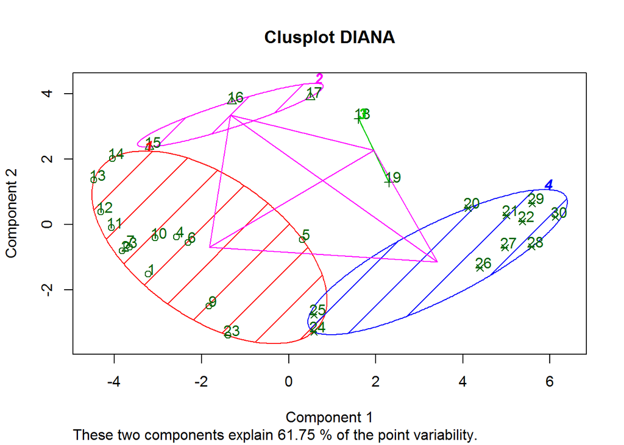

```r
clusplot(spe.norm, clas.diana, color = T, shade = T, labels = 2, lines = 1,
         main = "Clusplot DIANA")
```

```r
AdjRkl(clas.diana, spebc.ward.g)
```

```
## [1] 0.6016325
```

```r
#In the same table
clas.all <- cbind(spebc.ward.g, clas.agnes, clas.diana)
clas.all
```

```
##    spebc.ward.g clas.agnes clas.diana
## 1             1          1          1
## 2             1          1          1
## 3             1          1          1
## 4             1          1          1
## 5             2          2          1
## 6             1          1          1
## 7             1          1          1
## 9             2          2          1
## 10            1          1          1
## 11            1          1          1
## 12            1          1          1
## 13            1          1          1
## 14            1          1          1
## 15            2          2          2
## 16            2          2          2
## 17            2          2          2
## 18            2          2          3
## 19            2          2          3
## 20            3          3          4
## 21            3          3          4
## 22            3          3          4
## 23            4          4          1
## 24            4          4          4
## 25            4          4          4
## 26            3          3          4
## 27            3          3          4
## 28            3          3          4
## 29            3          3          4
## 30            3          3          4
```

# kmeans

Minimize the sum of squares from points to cluster centres Very sensitive to the initial centres, choose a nstart > 1 nstart -> avoid biaised center position by choosen many times

```r
spe.kmeans <- kmeans(spe.norm, centers = 4, nstart = 100)
spe.kmeans
```

```
## K-means clustering with 4 clusters of sizes 6, 12, 8, 3
##
## Cluster means:
##         Cogo        Satr       Phph       Neba        Thth        Teso
## 1 0.06167791 0.122088022 0.26993915 0.35942538 0.032664966 0.135403325
## 2 0.10380209 0.542300691 0.50086515 0.43325916 0.114024105 0.075651573
## 3 0.00000000 0.006691097 0.02506109 0.06987391 0.006691097 0.006691097
## 4 0.00000000 0.000000000 0.00000000 0.00000000 0.000000000 0.000000000
##         Chna       Chto       Lele      Lece       Baba      Spbi
## 1 0.06212775 0.21568957 0.25887226 0.2722562 0.15647062 0.1574388
## 2 0.00000000 0.00000000 0.06983991 0.1237394 0.02385019 0.0000000
## 3 0.10687104 0.09377516 0.14194394 0.2011411 0.24327992 0.1326062
## 4 0.05205792 0.00000000 0.07647191 0.3166705 0.00000000 0.0000000
##         Gogo       Eslu       Pefl      Rham       Legi       Scer
## 1 0.16822286 0.12276089 0.17261621 0.0793181 0.06190283 0.04516042
## 2 0.05670453 0.04722294 0.02949244 0.0000000 0.00000000 0.00000000
## 3 0.28386032 0.20630360 0.16920496 0.2214275 0.19066542 0.13171275
## 4 0.20500174 0.07647191 0.00000000 0.0000000 0.05205792 0.07647191
##         Cyca       Titi       Abbr      Icme       Acce       Ruru
## 1 0.06190283 0.14539027 0.01473139 0.0000000 0.03192175 0.32201597
## 2 0.00000000 0.03833408 0.00000000 0.0000000 0.00000000 0.01049901
## 3 0.16019126 0.26230024 0.19561641 0.1331835 0.26713081 0.32103755
## 4 0.00000000 0.00000000 0.00000000 0.0000000 0.18058775 0.31667052
##         Blbj      Alal       Anan
## 1 0.01473139 0.1095241 0.04739636
## 2 0.00000000 0.0000000 0.00000000
## 3 0.22883055 0.3326939 0.18873077
## 4 0.05205792 0.7618709 0.00000000
##
## Clustering vector:
##  1  2  3  4  5  6  7  9 10 11 12 13 14 15 16 17 18 19 20 21 22 23 24 25 26
##  2  2  2  2  1  2  2  1  2  2  2  2  2  2  1  1  1  1  3  3  3  4  4  4  3
## 27 28 29 30
##  3  3  3  3
##
## Within cluster sum of squares by cluster:
## [1] 1.7361453 2.5101386 0.4696535 0.3560423
##  (between_SS / total_SS =  66.7 %)
##
## Available components:
##
## [1] "cluster"      "centers"      "totss"        "withinss"
## [5] "tot.withinss" "betweenss"    "size"         "iter"
## [9] "ifault"
```

cluster sum of squares -> closer to 0 is an homogeneous group

```r
#Different objects
spe.kmeans$cluster
```

```
##  1  2  3  4  5  6  7  9 10 11 12 13 14 15 16 17 18 19 20 21 22 23 24 25 26
##  2  2  2  2  1  2  2  1  2  2  2  2  2  2  1  1  1  1  3  3  3  4  4  4  3
## 27 28 29 30
##  3  3  3  3
```

```r
spe.kmeans$centers
```

```
##         Cogo        Satr       Phph       Neba        Thth        Teso
## 1 0.06167791 0.122088022 0.26993915 0.35942538 0.032664966 0.135403325
## 2 0.10380209 0.542300691 0.50086515 0.43325916 0.114024105 0.075651573
## 3 0.00000000 0.006691097 0.02506109 0.06987391 0.006691097 0.006691097
## 4 0.00000000 0.000000000 0.00000000 0.00000000 0.000000000 0.000000000
##         Chna       Chto       Lele      Lece       Baba      Spbi
## 1 0.06212775 0.21568957 0.25887226 0.2722562 0.15647062 0.1574388
## 2 0.00000000 0.00000000 0.06983991 0.1237394 0.02385019 0.0000000
## 3 0.10687104 0.09377516 0.14194394 0.2011411 0.24327992 0.1326062
## 4 0.05205792 0.00000000 0.07647191 0.3166705 0.00000000 0.0000000
##         Gogo       Eslu       Pefl      Rham       Legi       Scer
## 1 0.16822286 0.12276089 0.17261621 0.0793181 0.06190283 0.04516042
## 2 0.05670453 0.04722294 0.02949244 0.0000000 0.00000000 0.00000000
## 3 0.28386032 0.20630360 0.16920496 0.2214275 0.19066542 0.13171275
## 4 0.20500174 0.07647191 0.00000000 0.0000000 0.05205792 0.07647191
##         Cyca       Titi       Abbr      Icme       Acce       Ruru
## 1 0.06190283 0.14539027 0.01473139 0.0000000 0.03192175 0.32201597
## 2 0.00000000 0.03833408 0.00000000 0.0000000 0.00000000 0.01049901
## 3 0.16019126 0.26230024 0.19561641 0.1331835 0.26713081 0.32103755
## 4 0.00000000 0.00000000 0.00000000 0.0000000 0.18058775 0.31667052
##         Blbj      Alal       Anan
## 1 0.01473139 0.1095241 0.04739636
## 2 0.00000000 0.0000000 0.00000000
## 3 0.22883055 0.3326939 0.18873077
## 4 0.05205792 0.7618709 0.00000000
```

```r
spe.kmeans$totss
```

```
## [1] 15.24268
```

```r
spe.kmeans$withinss
```

```
## [1] 1.7361453 2.5101386 0.4696535 0.3560423
```

```r
spe.kmeans$tot.withinss
```

```
## [1] 5.07198
```

```r
spe.kmeans$betweenss #totss - tot.withinss
```

```
## [1] 10.17071
```

```r
spe.kmeans$iter
```

```
## [1] 2
```

## kmeans VS Ward

```r
table(spe.kmeans$cluster, spebc.ward.g)
```

```
##    spebc.ward.g
##      1  2  3  4
##   1  0  6  0  0
##   2 11  1  0  0
##   3  0  0  8  0
##   4  0  0  0  3
```

```r
#Agree except with one

cbind(spe.kmeans$cluster, spebc.ward.g)
```

```
##      spebc.ward.g
## 1  2            1
## 2  2            1
## 3  2            1
## 4  2            1
## 5  1            2
## 6  2            1
## 7  2            1
## 9  1            2
## 10 2            1
## 11 2            1
## 12 2            1
## 13 2            1
## 14 2            1
## 15 2            2
## 16 1            2
## 17 1            2
## 18 1            2
## 19 1            2
## 20 3            3
## 21 3            3
## 22 3            3
## 23 4            4
## 24 4            4
## 25 4            4
## 26 3            3
## 27 3            3
## 28 3            3
## 29 3            3
## 30 3            3
```

```r
#See which individuals are not classified in the same group

AdjRkl(spebc.ward.g, spe.kmeans$cluster)
```

```
## [1] 0.8937271
```

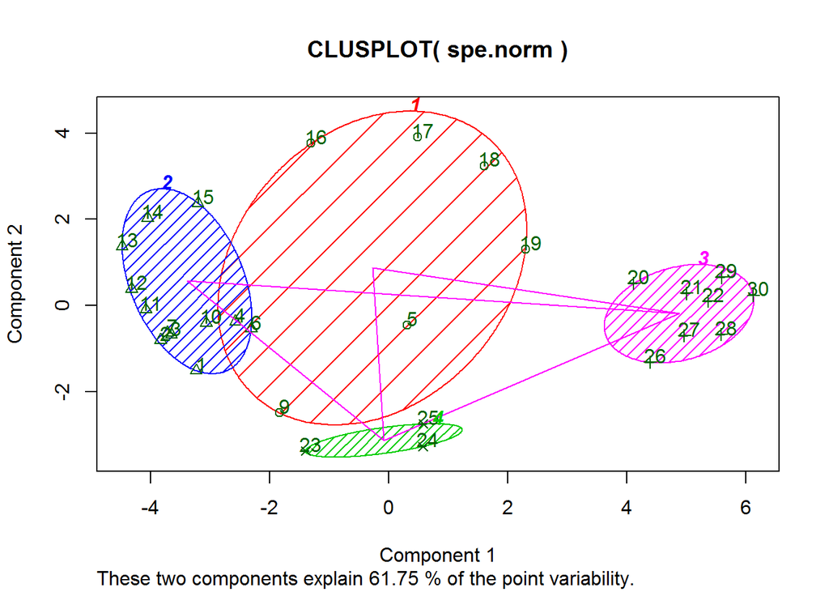

```r
#Very close to 1 --> Method agree

clusplot(spe.norm, spe.kmeans$cluster, color = T, shade = T, labels = 2, lines = 1)
```

```r
#Same graph as Ward method
```

## Plot of the 4 k-means clusters on a map of the Doubs river

[figure not shown]

```r
cluster_map(spa, spe.kmeans$cluster)
```

## CascadeKM - Kmeans partitioning

Wrapper of the kmeans function. Creates several partitions forming a cascade from a small to a large number of groups

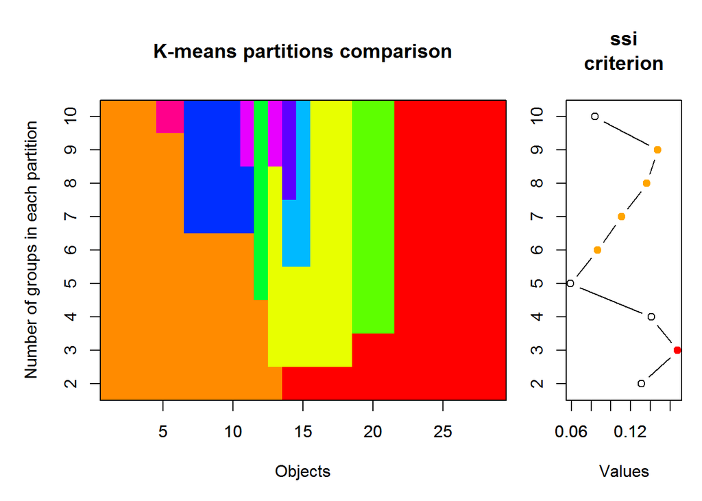

```r
spe.KM.cascade <- cascadeKM(spe.norm, inf.gr = 2, sup.gr = 10, iter = 100, criterion = "ssi")
par(mfrow = c(1,1))
plot(spe.KM.cascade, sortg = T)
```

If you want two groups -> horizontal line from two groups (y axis) and see how many objects are classed into two groups If you want four groups -> same method Choose the number of cluster where the ssi are higher –> well diferenciated groups Here : 3 but is it really better than 4 groups? Need knowledge in ecology

## ratio between sum of squares

```r
summary(spe.KM.cascade)
```

```
##           Length Class  Mode
## partition 261    -none- numeric
## results    18    -none- numeric
## criterion   1    -none- character
## size       90    -none- numeric
```

```r
names(spe.KM.cascade)
```

```
## [1] "partition" "results"   "criterion" "size"
```

```r
spe.KM.cascade$results
```

```
##      2 groups  3 groups  4 groups   5 groups   6 groups  7 groups
## SSE 8.2149405 6.4768108 5.0719796 4.30155732 3.58561200 2.9523667
## ssi 0.1312111 0.1675852 0.1409061 0.05927008 0.08641861 0.1107331
##      8 groups  9 groups  10 groups
## SSE 2.4840549 2.0521888 1.75992916
## ssi 0.1364312 0.1474273 0.08386358
```

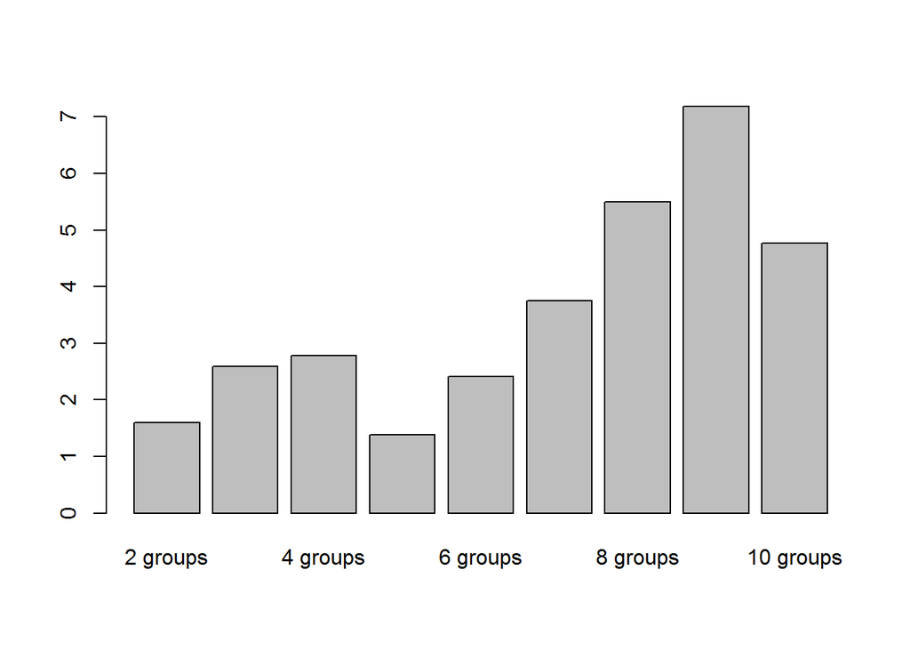

```r
ssi.sse <- spe.KM.cascade$results[2,]/spe.KM.cascade$results[1,]*100
barplot(ssi.sse)
```

```r
#Ratio must be lowest as possible
```

## Repartition of sites

```r
spe.KM.cascade$partition
```

```
##    2 groups 3 groups 4 groups 5 groups 6 groups 7 groups 8 groups 9 groups
## 1         2        3        1        1        6        2        4        9
## 2         2        3        1        2        5        4        2        1
## 3         2        3        1        2        5        4        2        1
## 4         2        3        1        2        5        4        2        1
## 5         1        2        3        4        3        7        8        7
## 6         2        3        1        2        5        4        2        1
## 7         2        3        1        2        5        4        2        1
## 9         1        2        3        4        3        7        7        8
## 10        2        3        1        2        5        4        2        1
## 11        2        3        1        2        5        5        6        2
## 12        2        3        1        2        5        5        6        2
## 13        2        3        1        2        5        5        6        2
## 14        2        3        1        2        5        5        6        2
## 15        2        3        1        2        5        5        6        5
```

[output cut: 45 more lines]

# Partitioning Around Medoids - PAM

A more robust version of kmeans

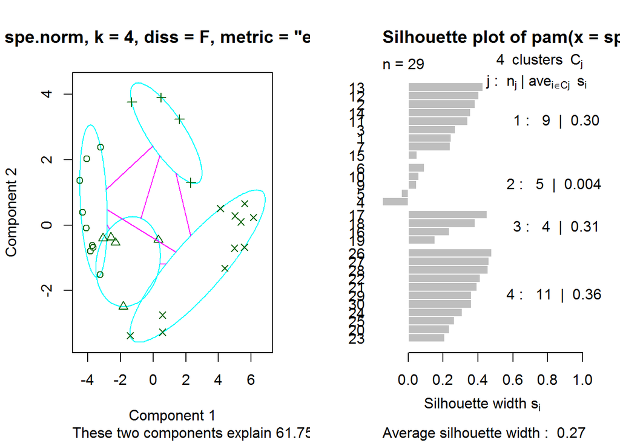

```r
spe.pam <- pam(spe.norm, 4, diss = F, metric = "euclidian", stand = F)
par(mfrow=c(1,2))
plot(spe.pam)
```

```r
spe.pam
```

```
## Medoids:
##    ID       Cogo      Satr      Phph       Neba       Thth      Teso
## 12 11 0.24618298 0.6154575 0.4923660 0.49236596 0.24618298 0.0000000
## 6   6 0.00000000 0.3779645 0.5039526 0.62994079 0.00000000 0.0000000
## 17 16 0.09284767 0.1856953 0.3713907 0.37139068 0.09284767 0.1856953
## 26 25 0.00000000 0.0000000 0.0000000 0.09325048 0.00000000 0.0000000
##          Chna      Chto       Lele      Lece     Baba       Spbi
## 12 0.00000000 0.0000000 0.00000000 0.1230915 0.000000 0.00000000
## 6  0.00000000 0.0000000 0.12598816 0.2519763 0.000000 0.00000000
## 17 0.09284767 0.3713907 0.27854301 0.1856953 0.278543 0.37139068
## 26 0.09325048 0.0000000 0.09325048 0.1865010 0.186501 0.09325048
##          Gogo       Eslu       Pefl       Rham       Legi       Scer
## 12 0.00000000 0.00000000 0.00000000 0.00000000 0.00000000 0.00000000
## 6  0.12598816 0.12598816 0.12598816 0.00000000 0.00000000 0.00000000
## 17 0.09284767 0.09284767 0.18569534 0.09284767 0.09284767 0.00000000
## 26 0.27975144 0.18650096 0.09325048 0.18650096 0.18650096 0.09325048
##          Cyca       Titi     Abbr       Icme      Acce      Ruru     Blbj
## 12 0.00000000 0.00000000 0.000000 0.00000000 0.0000000 0.0000000 0.000000
## 6  0.00000000 0.25197632 0.000000 0.00000000 0.0000000 0.1259882 0.000000
## 17 0.09284767 0.09284767 0.000000 0.00000000 0.0000000 0.1856953 0.000000
## 26 0.09325048 0.27975144 0.186501 0.09325048 0.3730019 0.3730019 0.186501
##         Alal       Anan
## 12 0.0000000 0.00000000
## 6  0.0000000 0.00000000
## 17 0.1856953 0.09284767
## 26 0.4662524 0.18650096
## Clustering vector:
##  1  2  3  4  5  6  7  9 10 11 12 13 14 15 16 17 18 19 20 21 22 23 24 25 26
##  1  1  1  2  2  2  1  2  2  1  1  1  1  1  3  3  3  3  4  4  4  4  4  4  4
## 27 28 29 30
##  4  4  4  4
## Objective function:
##     build      swap
## 0.4426460 0.4390712
##
## Available components:
##  [1] "medoids"    "id.med"     "clustering" "objective"  "isolation"
##  [6] "clusinfo"   "silinfo"    "diss"       "call"       "data"
```